# Project 1

Rachel Zhang

2022-09-19

# **Introduction**

The United States Geological Survey(USGS) is a US government agency that collects and analyzes data on a variety of natural resources and hazards. Today, we will be using a dataset from the USGS to analyze records of past earthquakes. Within the dataset, there are 18 variables. There are variables that show the exact time and date that the earthquake occurred, and more variables that show magnitude, depth, and the significance of the earthquakes. The data is collected from seismographic networks, as well as self-report surveys that can measure the felt distance of the earthquake.

> For this investigation, we will be examining the earthquake significance as the outcome variable, and its relationship with three predictor variables: earthquake magnitude, depth, and epoch time(since January 1st of 1970).

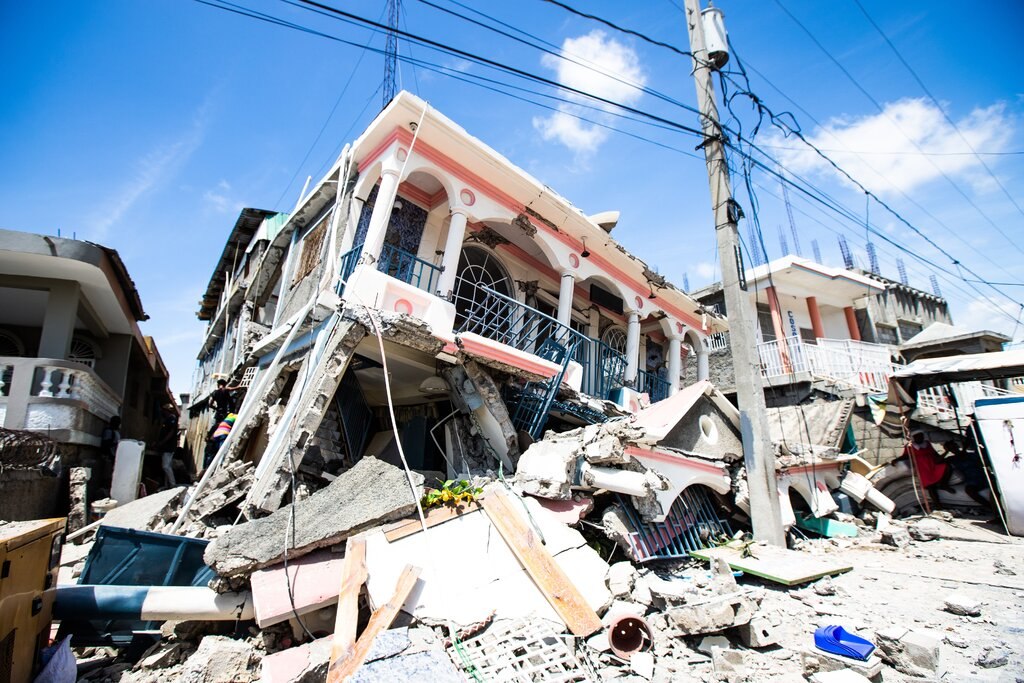

# **Earthquake Significance**

The significance of an earthquake is measured on a numeric scale, and it is determined by factors such as estimated impact, magnitude, and felt reports. The larger the number, the more significant the earthquake was.

> Let’s look at the distribution for the recorded significances of past earthquakes:

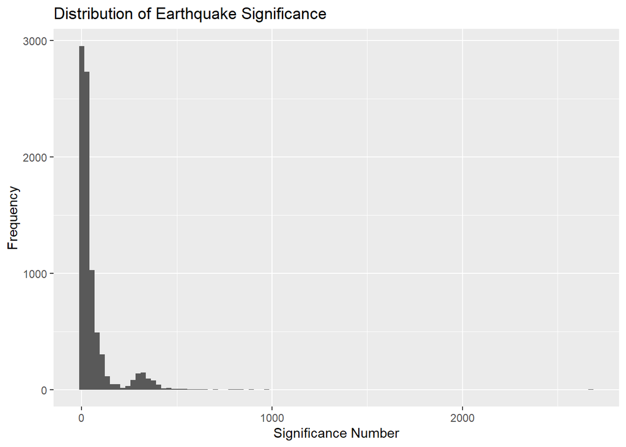

Here are the summary statistics for the distribution:

```
##    Min. 1st Qu.  Median    Mean 3rd Qu.    Max.
##    0.00    8.00   22.00   56.34   54.00 2674.00
```

and the standard deviation is 96.68. There is a bimodal distribution, however the first peak is *significantly* larger than the second one. As seen in the table, the first quartile is 8, 3rd quartile is 54, median is 22 and mean is approximately 56.34. The standard deviation is quite large and the mean is larger than the median, signifying that the data is also right skewed. Overall, it appears that majority of earthquakes recorded have relatively small significance.

# **Earthquake Magnitude vs. Significance**

> Next, let’s look at the relationship between earthquake magnitude and significance.

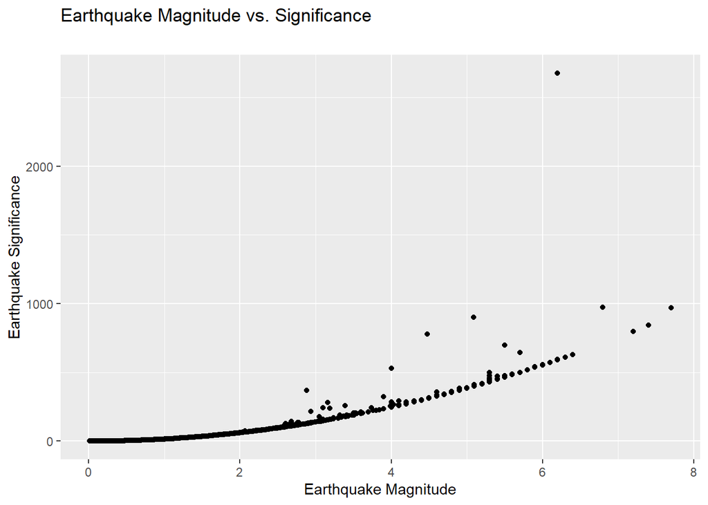

As mentioned before, the magnitude of the earthquake is a factor that is considered when estimating the significance. In the graph, we can see a very clear upward sloping curve, and there is a correlation coefficient of 0.91, which also shows that there is a strong positive correlation between the two variables. This makes sense, as it confirms that when the magnitude of the earthquake increases, the significance of the earthquake also tends to increase. When the magnitude is high, it likely means more damage and impact, thus causing the higher significance number.

# **Earthquake Depth vs. Significance**

> For the second predictor variable, we are going to examine the earthquake depth and the significance number.

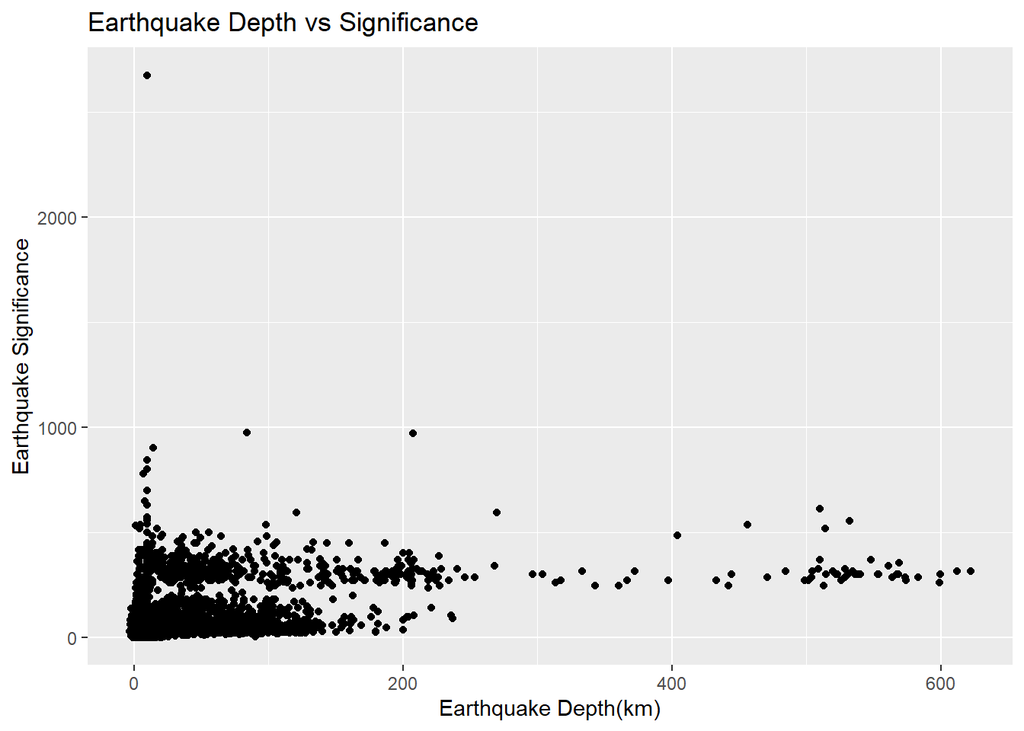

For this relationship, the correlation coefficient is 0.4. That means there is a moderate positive correlation between the two variables. As the earthquake depth increases, it is possible that the earthquake significance may increase. However, this may not always hold true because some strong earthquakes with large significance might not necessarily be at greater depths, and some small earthquakes with smaller significance might not necessarily be at shallow depths.

# **Epoch Time vs. Significance**

> Last, let’s examine the relationship between the epoch time a earthquake occurred and its significance.

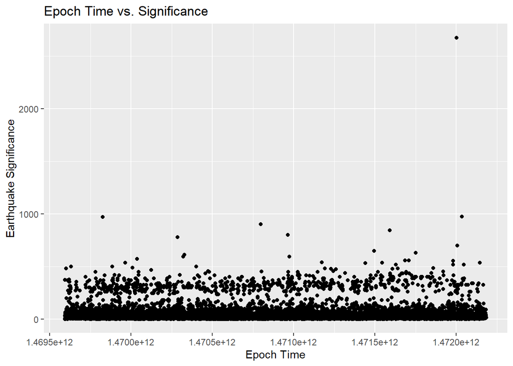

For this relationship, the correlation coefficient is 0.02, which signifies a very weak positive correlation between the two variables. As the epoch time increases(as more time goes by), the significance of the earthquakes may increase, however it is unlikely to occur directly because of the increase in time. In other words, it’s not likely that earthquakes will be more significant in the future just because of passing time.

# **Conclusion**

From this investigation, we examined the earthquake significance as an outcome variable, and analyzed its relationship with three different predictor variables: magnitude, depth, and epoch time.

Between magnitude and earthquake significance, there was a strong positive correlation, which made sense because magnitude is a factor that is used to gauge the impact of the earthquake. The stronger the magnitude of the earthquake, it is likely to have more significance.

For the earthquake depth and earthquake significance, there was less strong of a positive correlation. When the earthquake depth increases, it may cause higher significance because some strong earthquakes might occur at great depths, but that is not always the case. Some of the strongest earthquakes occur at shallower depths, and some weaker ones occur at deeper depths.

As for epoch time and earthquake significance, there was a very weak positive correlation between the two variables. As time goes by, there might be a few more significant earthquakes, but they likely do not get more significant just because of passing time.

Seeing that there isn’t a strong relationship between earthquake significance and epoch time, we could analyze the significance with the months instead, to see if there is a specific season or time of year that has more severe earthquakes. In the future, we can also investigate relationships between location variables and magnitude. For example, latitude and longitude with magnitude as a gradient to see the locations where earthquakes with the strongest magnitudes come from.

# **References**

Gladstone, M. A.-H. and R. (2021, August 23). Strong earthquake rocks Haiti, killing hundreds (published 2021). The New York Times. Retrieved September 21, 2022, from https://www.nytimes.com/live/2021/08/14/world/haiti-earthquake

Who we are. Who We Are | U.S. Geological Survey. (n.d.). Retrieved September 21, 2022, from https://www.usgs.gov/about/about-us/who-we-are